# 07 - One-way ANOVA

John Shorter

Feb/12/2026

# Introduction

If you want to compare the means of two samples, what do you do? You use the t-test. (We will cover that a bit later, don’t worry!)

However, what if you have three or more samples? This module goes over one-way ANOVA and Tukey tests, which is designed to compare multiple ( >= 2) samples.

1. How to set up a linear model?
2. What are the assumptions of linear model and how to check them?
3. How to interpret an ANOVA table?
4. How to set up a Tukey test?
5. How to interpret the compact letter display? -What it means and what it doesn’t mean.

# Load packagess

```r
# install.packages("emmeans")
# install.packages("multcomp")
# install.packages("multcompView")
# install.packages("viridis")
# remotes::install_github("allisonhorst/palmerpenguins") #download the data from GitHub
```

```r
library(emmeans) #four new packages you might need to install them
library(multcomp)
library(multcompView)
library(palmerpenguins)
```

```r
library(ggplot2)
library(tidyr)
library(dplyr)
library(readr)
library(readxl)
library(RColorBrewer)
library(viridis)
```

# Data

This time we’ll use the [penguins dataset](https://github.com/allisonhorst/palmerpenguins). Ref: [Gorman KB, Williams TD, Fraser WR (2014) PLoS ONE 9(3): e90081.](https://doi.org/10.1371/journal.pone.0090081).

```r
head(penguins)
```

```
## # A tibble: 6 × 8
##   species island    bill_length_mm bill_depth_mm flipper_length_mm body_mass_g
##   <fct>   <fct>              <dbl>         <dbl>             <int>       <int>
## 1 Adelie  Torgersen           39.1          18.7               181        3750
## 2 Adelie  Torgersen           39.5          17.4               186        3800
## 3 Adelie  Torgersen           40.3          18                 195        3250
## 4 Adelie  Torgersen           NA            NA                  NA          NA
## 5 Adelie  Torgersen           36.7          19.3               193        3450
## 6 Adelie  Torgersen           39.3          20.6               190        3650
## # ℹ 2 more variables: sex <fct>, year <int>
```

```r
str(penguins)
```

```
## tibble [344 × 8] (S3: tbl_df/tbl/data.frame)
##  $ species          : Factor w/ 3 levels "Adelie","Chinstrap",..: 1 1 1 1 1 1 1 1 1 1 ...
##  $ island           : Factor w/ 3 levels "Biscoe","Dream",..: 3 3 3 3 3 3 3 3 3 3 ...
##  $ bill_length_mm   : num [1:344] 39.1 39.5 40.3 NA 36.7 39.3 38.9 39.2 34.1 42 ...
##  $ bill_depth_mm    : num [1:344] 18.7 17.4 18 NA 19.3 20.6 17.8 19.6 18.1 20.2 ...
##  $ flipper_length_mm: int [1:344] 181 186 195 NA 193 190 181 195 193 190 ...
##  $ body_mass_g      : int [1:344] 3750 3800 3250 NA 3450 3650 3625 4675 3475 4250 ...
##  $ sex              : Factor w/ 2 levels "female","male": 2 1 1 NA 1 2 1 2 NA NA ...
##  $ year             : int [1:344] 2007 2007 2007 2007 2007 2007 2007 2007 2007 2007 ...
```

```r
penguins %>%
  group_by(species) %>%
  count()
```

```
## # A tibble: 3 × 2
## # Groups:   species [3]
##   species       n
##   <fct>     <int>
## 1 Adelie      152
## 2 Chinstrap    68
## 3 Gentoo      124
```

We will compare bill length across the three species and find out who (if anyone) has the longest bill.

This means species will be the independent variable, and bill length will be the dependent variable.

# Data visualization

First, it’s always a good idea to take a look at the data before you do any analysis.

Use what you learned last time to make the best plot possible. Use the format

penguins %>% #  
ggplot(aes(x = species, y = bill_length_mm)) + #  
geom_point(aes(fill = ), #What are the 3 things being compared?  
position = , #Maybe jitter our positions?  
alpha = , #Makes your dots transparent  
size = , #Make dots larger or smaller  
shape = , #Shape = 21 gives you open circle  
color = “…”) + #Border around each dot  
scale_f…_m…..(values = w….[c(..,..,..)]) + #This is where we can use the palette from last time  
labs() + #labels for our x and y axes  
theme_minimal() + #Keep it simple here, no need to add more  
theme(…) #Tweak some minor details, like our legend.position, if interested.

You should also use the palette you designed from the last activity

Make your plot here:

We can also take a quick look at the summary statistics

```r
length_summary <- penguins %>%
  filter(is.na(bill_length_mm) == F) %>%
  group_by(species) %>%
  summarise(
    mean = mean(bill_length_mm),
    var = var(bill_length_mm),
    sd = sd(bill_length_mm),
    n = n()
  )

head(length_summary)
```

```
## # A tibble: 3 × 5
##   species    mean   var    sd     n
##   <fct>     <dbl> <dbl> <dbl> <int>
## 1 Adelie     38.8  7.09  2.66   151
## 2 Chinstrap  48.8 11.2   3.34    68
## 3 Gentoo     47.5  9.50  3.08   123
```

# Data check

To perform an ANOVA, the dependent variable must be numeric, and the independent variable must be categorical (or discrete factor). Can you check that?

```r
str(penguins)
```

```
## tibble [344 × 8] (S3: tbl_df/tbl/data.frame)
##  $ species          : Factor w/ 3 levels "Adelie","Chinstrap",..: 1 1 1 1 1 1 1 1 1 1 ...
##  $ island           : Factor w/ 3 levels "Biscoe","Dream",..: 3 3 3 3 3 3 3 3 3 3 ...
##  $ bill_length_mm   : num [1:344] 39.1 39.5 40.3 NA 36.7 39.3 38.9 39.2 34.1 42 ...
##  $ bill_depth_mm    : num [1:344] 18.7 17.4 18 NA 19.3 20.6 17.8 19.6 18.1 20.2 ...
##  $ flipper_length_mm: int [1:344] 181 186 195 NA 193 190 181 195 193 190 ...
##  $ body_mass_g      : int [1:344] 3750 3800 3250 NA 3450 3650 3625 4675 3475 4250 ...
##  $ sex              : Factor w/ 2 levels "female","male": 2 1 1 NA 1 2 1 2 NA NA ...
##  $ year             : int [1:344] 2007 2007 2007 2007 2007 2007 2007 2007 2007 2007 ...
```

Our dependent variable, bill length is indeed numeric “num”; Our independent variable species is indeed Factor. So all is good.

## Setting up a liner model

To perform an ANOVA in R, a good way to start is to set up a linear model first. In a one-way ANOVA, it follows the form `lm(y ~ x)`, where `lm` stands for linear model, y is dependent variable, x is independent variable.

```r
model_bill.length <- lm(bill_length_mm ~ species, data = penguins)
# don't forget to specify which data using data = argument
```

OK, so now we have a model. If you look into the environment, you’ll see the model is a list of bunch of different stuff. Let’s not worry about what’s in it for now.

## Assumtions of ANOVA and how to check them

ANOVA, like any statistical methods, have a few assumptions. I’m listing them out first and will explain them one by one

1. Independence: this means the measurement of one observation does not affect the other. In this example, we can only assume that’s the case. Looking at the data table, there is no indication of not the case. However, for example, if the same animal is measured twice, then it will violate the assumption of independence. So in that case, you should first average across the repeated measures. We’ll cover more about this when we learn about repeated measures later on.
2. Normality: the residues (errors) are normally distributed. Note: this is different from “the data is normally distributed”. What this actually means is after the means are computed, the ERROR around the means (the residues) have to be normally distributed. The sample means don’t have to be normally distributed.

How do I check that?

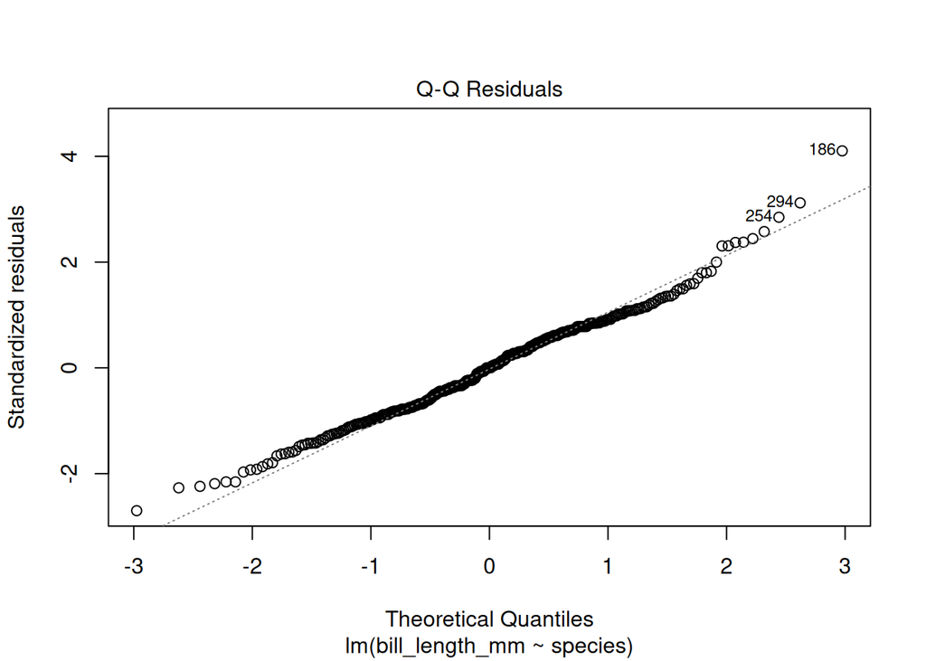

```r
plot(model_bill.length, which = 2)
```

This is called a normal qq plot. Or normal quantile-quantile plot. The quantiles of a normal distribution is plotted on x axis. The quantiles of the model is plotted on the y axis. If the residues are normally distributed, the dots will fall on a straight line across the diagonal. Looks pretty good. In this model, the residues are normally distributed.

If you are not sure, you can simulate normqq plots from a few normal distribution and check for yourself.

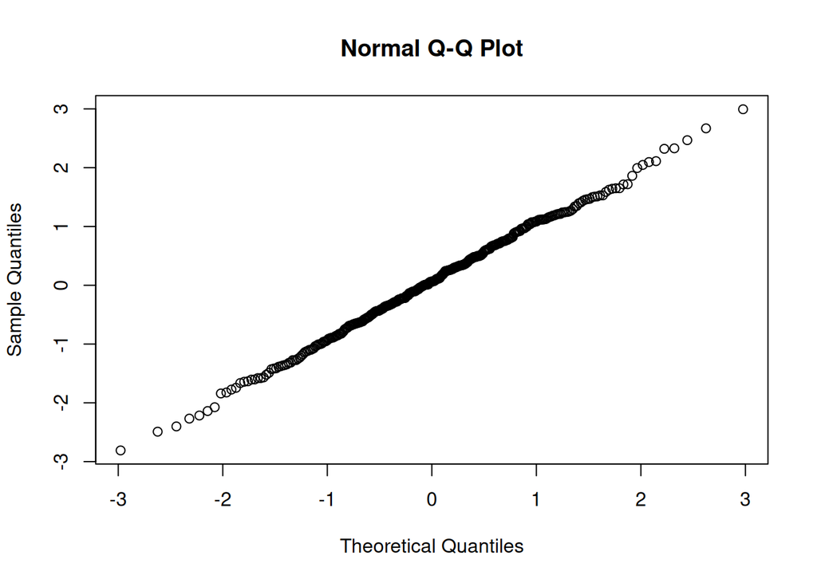

```r
rnorm(mean = 0, sd = 1, n = nrow(penguins)) %>% qqnorm()
```

The code `rnorm()` generates normally distributed randon numbers. The `n = nrow(penguins)` argument generate the same number of data points as in penguins data. Every time you run the above chuck the output will be different, because the numbers are randomly generated. Run it several times to have an idea of what normally distributed data should look like.

3. The last assumption is homoscedasticity: equal variance across groups. This may seen a bit abstract, but in fact it is very straightforward for one-way ANOVA. In this example, we have three groups, that is, three species. And equal variance would be the three species have roughly the same variance. How do I check that?

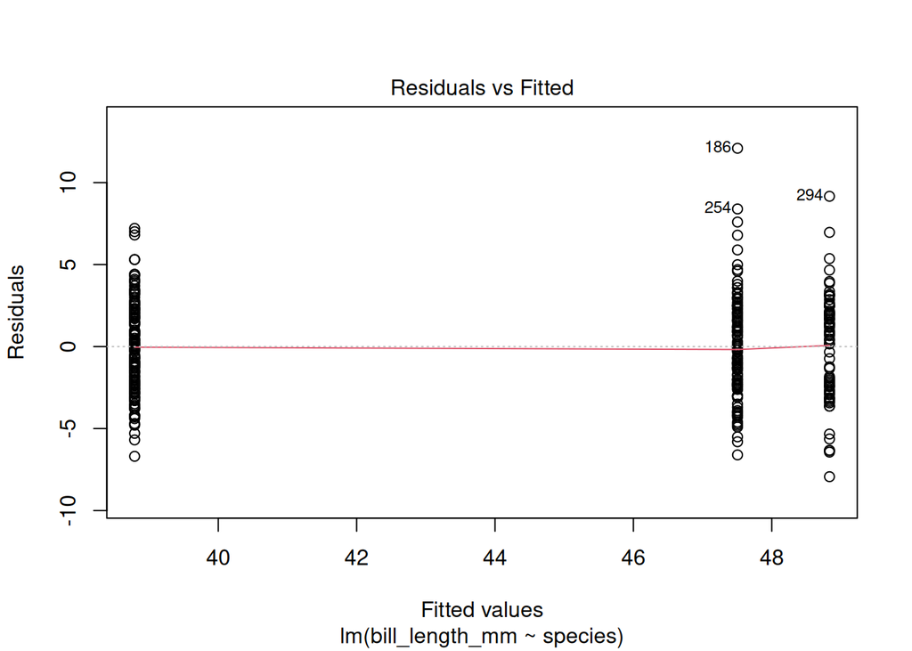

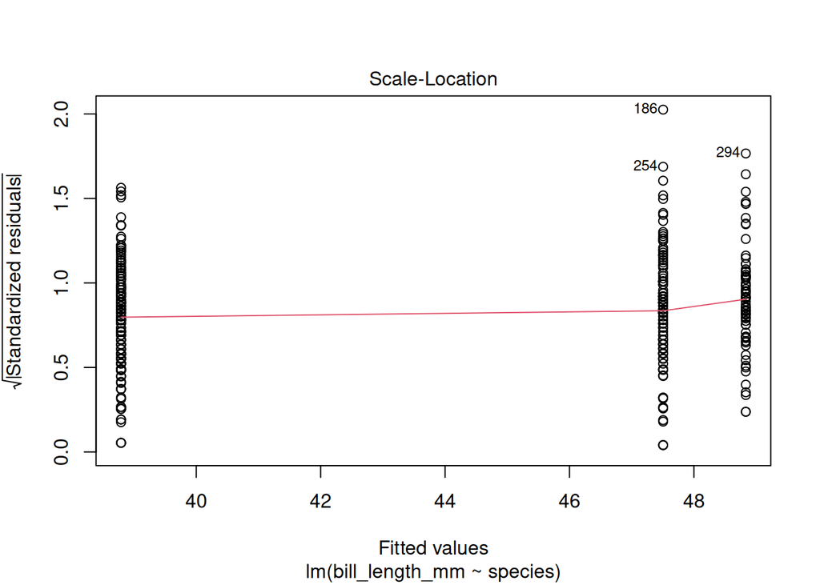

```r
plot(model_bill.length, which = c(1, 3))
```

The first graph is called residues vs. Fitted. It is plotting the means of groups (in this case species) on x axis, and the spread of errors on the y axis. If the variances are equal, you should see roughly same amount of spread across the line. It looks fine to me.

The second graph is called scale location. Again x axis is still the means of groups, but the y axis is now square root of absolute values of errors. If the variances are equal, you should see roughly a flat line. It looks more or less fine to me.

So great! We are all clear to do an ANOVA!

## How to interpret an ANOVA table

```r
anova(model_bill.length)
```

```
## Analysis of Variance Table
##
## Response: bill_length_mm
##            Df Sum Sq Mean Sq F value    Pr(>F)
## species     2 7194.3  3597.2   410.6 < 2.2e-16 ***
## Residuals 339 2969.9     8.8
## ---
## Signif. codes:  0 '***' 0.001 '**' 0.01 '*' 0.05 '.' 0.1 ' ' 1
```

This is the output of an ANOVA. It’s a table. How do I read this?

In the applied sense, the most important number is the F value. The F value is computed by mean sum of squares of dependent variable (species in this case). over the mean sum of squares of residues, so 3597/8.8 = 410.

The F value can be (loosely) understood as the variance between groups over the variances within group. The null hypothesis is F = 1. This means there is equal variation between groups and within groups.

In this example we have F = 410, which is >> 1. The p value, or Pr(>F) is the probability of finding F values more extreme than observed F value, if F = 1. In this case we have F = 410, if F were equal to 1, the probability of finding F > 410 is < 2.2e-16. So very small. Thus, we should reject the null hypothesis of F = 1.

This means the means of different species are different.

## How to do Tukey test

“The simple graph has brought more information to the data analyst’s mind than any other device.” — John Tukey

ANOVA has told us the means of different penguin species are different. But it didn’t tell us which one is the greatest. To find that out, we need to use Tukey test

```r
estimate_bill <- emmeans(model_bill.length, pairwise ~ species)
```

The `emmeans` function means estimate marginal means. The underlying math is actually pretty complex, but for the applied sense, it can be loosely understood as estimate the means of different groups.

In the `emmeans` function, you will call which model you want to estimate, in this case `model_bill.length`. You will call what type of comparisons we want to make, and usually it is pairwise, meaning all pairwise contrasts. Lastly, you will call which variable you want to compare across. In this case species.

We estimated the means, now we can compare the means.

```r
estimate_bill$contrasts
```

```
##  contrast           estimate    SE  df t.ratio p.value
##  Adelie - Chinstrap   -10.04 0.432 339 -23.232 <0.0001
##  Adelie - Gentoo       -8.71 0.360 339 -24.237 <0.0001
##  Chinstrap - Gentoo     1.33 0.447 339   2.971  0.0089
##
## P value adjustment: tukey method for comparing a family of 3 estimates
```

The is the output of Tukey tests. Again a table.

The contrast column should be self-explanatory: what is compared to what? The estimate column is the differences of means. The SE column is standard error of differences of means. The df column is degrees of freedom.

In the most applied sense, the most important numbers are the t.ratio. t ratio is (the difference in mean) / SE. For example, in row 1, t = -10.04 / 0.432 = -23. The null hypothesis is t = 0, meaning no difference in mean.

The p.value means if t = 0, given the degrees of freedom, what is the probability of getting a t.ratio more extreme than what’s observed?

For example, in row 1, we have t = -23, if t were to be 0, the probability of finding t < -23 and more extreme is <0.0001. Very small. So we should reject the null hypothesis.

Keep in mind that Tukey tests give you the adjusted P values for multiple comparisons. In this example, “P value adjustment: tukey method for comparing a family of 3 estimates”. What does this mean?

Because we have three species, we have three comparisons, they are:

1. Adelie - Chinstrap,
2. Adelie - Gentoo,
3. Chinstrap - Gentoo

Under a p = 0.05 cutoff, if each comparison has an type I error rate of 0.05, in three tests you have a total type I error rate of 0.05 * 3 = 0.15. Keep in mind that when you run a Tukey tests, R will take care of that, and the p values are already adjusted, so that the total type I error rate of your analysis is still 0.05.

So what do we learn from the table? -The means of the three species are all significantly different from each other.

## How do I report the resuls of a Tukey test?

You can directly report the contrast table. That’s fine. However, there is another way, that is “compact letter display”. The compact letter display method is used in scientific publications a lot. It’s important that you know what it means and what it doesn’t mean.

You will call the `cld` (stands for compact letter display) function, and put in the `emmeans` as the argument.

```r
cld(estimate_bill$emmeans, Letters = letters)
```

```
##  species   emmean    SE  df lower.CL upper.CL .group
##  Adelie      38.8 0.241 339     38.3     39.3  a
##  Gentoo      47.5 0.267 339     47.0     48.0   b
##  Chinstrap   48.8 0.359 339     48.1     49.5    c
##
## Confidence level used: 0.95
## P value adjustment: tukey method for comparing a family of 3 estimates
## significance level used: alpha = 0.05
## NOTE: If two or more means share the same grouping symbol,
##       then we cannot show them to be different.
##       But we also did not show them to be the same.
```

How do I interpret this output? The emmean column is the estimated means. The lower.CL and upper.CL are the confidence limits; together they mark the 95% confidence interval of the mean. Lastly, there is the “.group” column - how to interpret it?

If two rows share the same letter, it means the means of that two groups are not statistically different. In this example, each species has their own unique letter, so the means of the species are all significantly different from each other, consistent with what the contrasts told us.

We can conclude that the species Chinstrap has the longest bill, and the species Adelie has the shortest.

As a practice, let’s try a hypothetical example. In this cld, we have

sample1 | a |  
sample2 | ab |  
sample3 | b |  
sample4 | c |

What does this mean?

It means:

- The means of sample1 and sample2 are not significantly different, because they both share the letter “a”.
- The means of sample2 and sample3 are not significantly different, because they both share the letter “b.
- The means of sample4, however, is significantly different from sample1, 2 and 3, because it has the unique letter “c”.

Be *VERY CAREFUL* when you interpret a cld output. Two samples sharing the same letter does NOT mean their means are equal! It only means their means are not significantly different in this experiment. Their means might actually be different -  
it’s just the experiment didn’t have enough power to detect that difference.

## Publication quality reporting

Now let’s make a pretty plot and include the results of statistics as well

```r
# I'm going to use my wisteria palette
wisteria <- c("grey65", "burlywood3", "khaki2", "plum1", "lightcyan2", "cornflowerblue", "slateblue3")
```

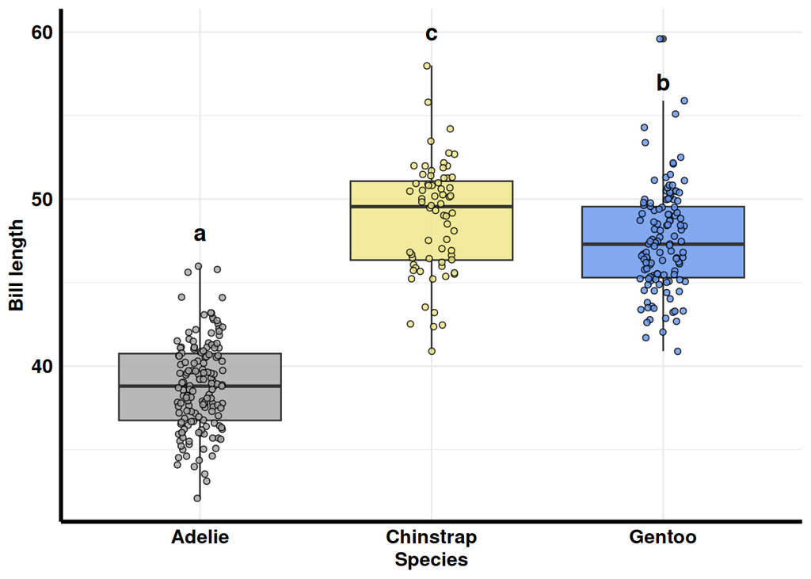

```r
penguins %>%
  ggplot(aes(x = species, y = bill_length_mm)) +
  geom_boxplot(aes(fill = species),            #You can make a box plot too!
               alpha = 0.8, width = 0.7) +
  geom_point(aes(fill = species), shape = 21, color = "black", alpha = 0.8,
             position = position_jitter(width = 0.1, seed = 666)) +
  annotate(geom = "text",     #you can use the annotate funtion to add the letter grouping of cld
           label = c("a", "c", "b"),
           x = c(1, 2, 3),             #you can also do this in PPT or illustrator or Inkscape
           y = c(48, 60, 57),
           size = 5, fontface = "bold") +
  scale_fill_manual(values = wisteria[c(1, 3, 6)]) +
  labs(x = "Species",
       y = "Bill length") +
  theme_minimal() +
  theme(legend.position = "none",
        axis.line = element_line(linewidth = 1.2),
        text = element_text(size = 12, color = "black", face = "bold"),
        axis.text = element_text(size = 12, color = "black", face = "bold")
        )
```

So this will be a publication quality graph.

As a rule of thumb, in each group, if n < 10, then you just use jittered dots. If n > 10 but < 1000, it’s a good idea to show the boxplot, or all the dots, or both. If n > 1000 per group, then just use the box plot with no dots. It’s too many dots to look at.

# Exercise

Now try it out yourself! Compare the bill depth across the three species and find out which one has the deepest bill.

## Visualize the data

[figure not shown]

```r
penguins %>%
  ggplot(aes(x = species, y = bill_depth_mm)) +
  geom_boxplot(aes(fill = species),            #You can make a box plot too!
               alpha = 0.8, width = 0.7) +
  geom_point(aes(fill = species), shape = 21, color = "black", alpha = 0.8,
             position = position_jitter(width = 0.1, seed = 666)) +
  annotate(geom = "text",     #you can use the annotate funtion to add the letter grouping of cld
           label = c("a", "c", "b"),
           x = c(1, 2, 3),             #you can also do this in PPT or illustrator or Inkscape
           y = c(24, 24, 24),
           size = 5, fontface = "bold") +
  scale_fill_manual(values = wisteria[c(1, 3, 6)]) +
  labs(x = "Species",
       y = "Bill depth") +
  theme_minimal() +
  theme(legend.position = "none",
        axis.line = element_line(linewidth = 1.2),
        text = element_text(size = 12, color = "black", face = "bold"),
        axis.text = element_text(size = 12, color = "black", face = "bold")
        )
```

## Set up the linear model and check assumptions

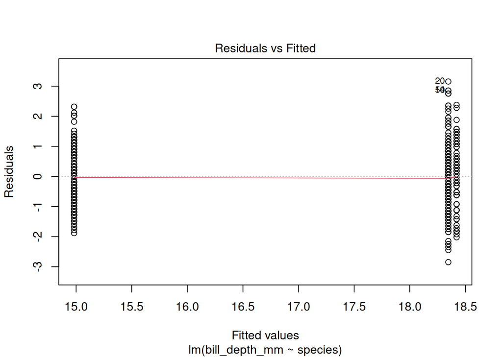

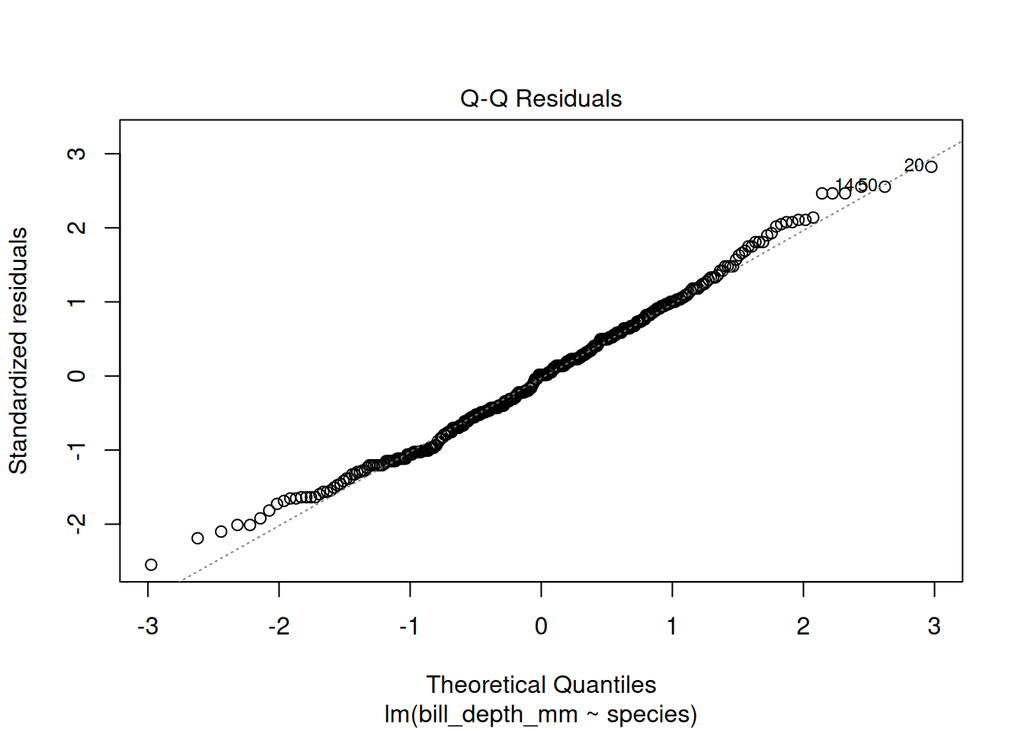

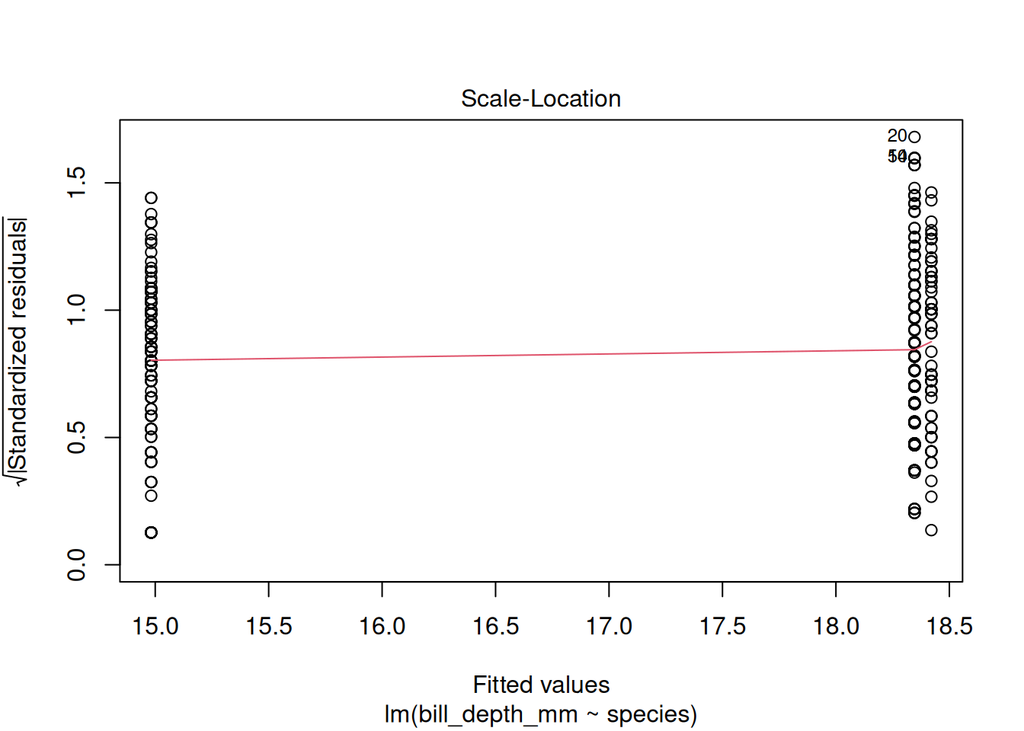

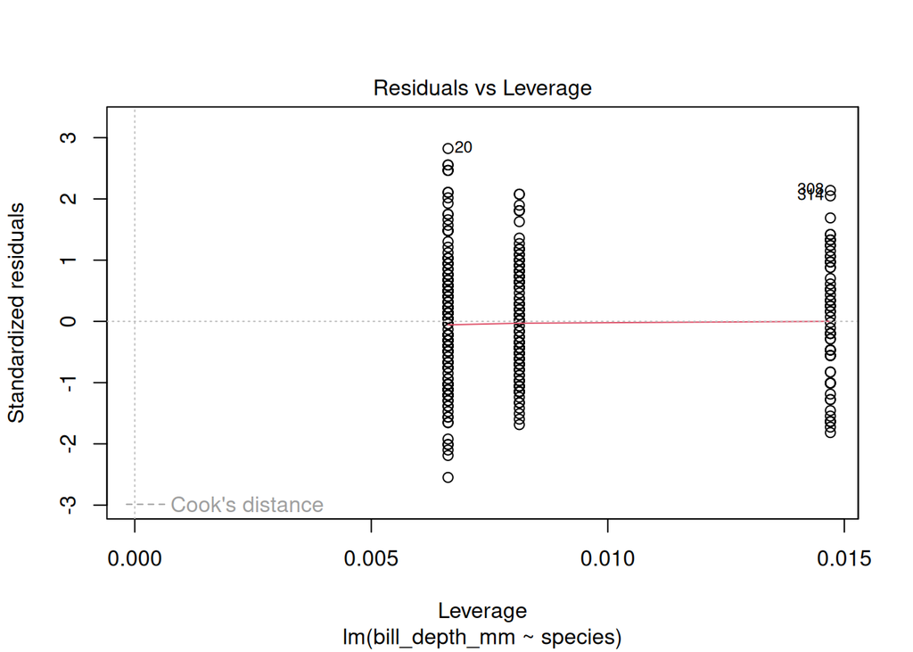

```r
model_bill_depth <- lm(bill_depth_mm ~ species, data = penguins)
plot(model_bill_depth)
```

### interpretation

Residuals look to be equally distributed in plots 1 and 3, and the qq plot also shows good agreement with normal distribution residuals, and we don’t see any outliers. Plot 4 can also be used to detect outliers.

## Run ANOVA and interpret the ANOVA table

```r
anova(model_bill_depth)
```

```
## Analysis of Variance Table
##
## Response: bill_depth_mm
##            Df Sum Sq Mean Sq F value    Pr(>F)
## species     2 903.97  451.98  359.79 < 2.2e-16 ***
## Residuals 339 425.87    1.26
## ---
## Signif. codes:  0 '***' 0.001 '**' 0.01 '*' 0.05 '.' 0.1 ' ' 1
```

The F value is quite big (359.8), showing that the between group variance is higher than within group variance, and thus due to the resulting small P value from matching the F value to an F distribution with appropriate degrees of freedom we reject the null hypothesis of the means being equal.

## Run Tukey tests and interpret the contrast

```r
estimate_bill_length <- emmeans(model_bill_depth, pairwise ~ species)
estimate_bill_length$contrasts
```

```
##  contrast           estimate    SE  df t.ratio p.value
##  Adelie - Chinstrap  -0.0742 0.164 339  -0.453  0.8929
##  Adelie - Gentoo      3.3642 0.136 339  24.712 <0.0001
##  Chinstrap - Gentoo   3.4385 0.169 339  20.301 <0.0001
##
## P value adjustment: tukey method for comparing a family of 3 estimates
```

The contrasts show a significant p value for Gentoo vs both Chinstrap and Adelie, but not for Adelie and Chinstrap.

## Report the compact letter display and interpret the cld output

```r
cld(estimate_bill_length, Letters = letters)
```

```
##  species   emmean     SE  df lower.CL upper.CL .group
##  Gentoo      15.0 0.1010 339     14.8     15.2  a
##  Adelie      18.3 0.0912 339     18.2     18.5   b
##  Chinstrap   18.4 0.1360 339     18.2     18.7   b
##
## Confidence level used: 0.95
## P value adjustment: tukey method for comparing a family of 3 estimates
## significance level used: alpha = 0.05
## NOTE: If two or more means share the same grouping symbol,
##       then we cannot show them to be different.
##       But we also did not show them to be the same.
```

Adelie and Chinstrap are in the same group, no significant difference between their bill depths. Gentoo has the smallest bill depth.

## What to submit to Moodle (Pass/Fail)

For this lesson, complete the exercises **in your shared Exercise Pack** (the file `Exercise_Pack_Template.Rmd`). Then **Knit to HTML** and upload the HTML file to the Moodle exercise folder.

**File name format:** `Lastname_Firstname_L07.html`

### Satisfactory / Not satisfactory (what I check)

Your submission is **Satisfactory** if:

- It **knits** (HTML opens and shows your work).
- You included **outputs** (plots/tables/model output) that match the lesson.
- You answered the **Self-check checklist** (short, honest, and complete).
- Your work is **plausible** (right method for the lesson, correct variables, no obvious copy/paste without results).

### Exercise 2 — A different outcome

Repeat the one-way ANOVA workflow using a different numeric outcome (same dataset).

**Self-check:** you show a plot + model output + ANOVA table.

### Exercise 3 — Assumptions and alternatives

Check assumptions (normality of residuals and equal variance). If one assumption looks poor, try one reasonable alternative (transformation or non-parametric test) and compare conclusions.

**Self-check:** you show at least one diagnostic plot and explain what changed.

### Exercise 4 — Report like a paper (short)

Write 3–5 sentences reporting: - what groups were compared - the test used - the main result (direction + p-value) - what post-hoc test showed

**Self-check:** your report includes both statistics and interpretation.

### Exercise 5 — Mini-transfer

Pick a different built-in dataset (e.g., `iris`) and run one-way ANOVA on a sensible outcome by group.

**Self-check:** group variable is a factor; you include a plot and an ANOVA table.